# Asesinatos por cuestión de género

Ensañamiento y distribución por provincia

Author

Erika Hendrickse

Published

October 15, 2025

## 1 Introducción y objetivos

El dataset seleccionado para trabajar brinda datos sobre asesinatos por motivo de género, tanto femicidios como homicidios y trans/travesticidios, entre los años 2012 y 2019 en Argentina. A partir de esta información se construyeron tres preguntas:

- a) ¿Qué genero registra mayor cantidad de asesinatos por motivo de genero?
- b) ¿Que genero registra mayor ensañamiento según modalidad de asesinato?
- c) ¿En qué provincias de Argentina hay más femicidios?

## 2 Pasos a seguir

1. Carga y exploración del dataset
2. Limpieza y preparación
3. Construcción de obetos visuales

## 3 Carga y exploración del dataset

3.1. Cargo el dataset

```r
url_1 <- "https://datos.jus.gob.ar/dataset/27bb9b2c-521b-406c-bdf9-98110ef73f34/resource/583cec9a-3022-4234-8b32-17692a267aac/download/registro-de-femicidios-20200109.csv"
df_1 <- read.csv(url_1)
```

3.1. Cargo librerías

```r
library(tidyverse)
library(dplyr)
library(purrr)
```

3.3. Exploro la estructura del dataset

```r
glimpse(df_1)
```

```
Rows: 1,325
Columns: 10
$ caso_numero              <int> 310, 402, 237, 565, 594, 703, 38, 31, 44, 14,…
$ victima_edad             <int> 47, 7, 18, 46, 27, 42, 22, 41, NA, NA, 44, 45…
$ victima_identidad_genero <chr> "MUJER", "HOMBRE", "MUJER", "MUJER", "MUJER",…
$ victima_tipo             <chr> "PRINCIPAL", "VINCULADO", "PRINCIPAL", "PRINC…
$ hecho_provincia          <chr> "Río Negro", "Córdoba", "Santa Fe", "", "Neuq…
$ hecho_modalidad_comisiva <chr> "GOLPES", "ACUCHILLAMIENTO", "DISPARO DE BALA…
$ hecho_fecha              <chr> "2014-11-20", "2015-08-04", "2014-11-02", "20…
$ fuente_tipo              <chr> "MEDIO COMUNICACIÓN", "MEDIO COMUNICACIÓN", "…
$ fuente_link              <chr> "http://www.diariouno.com.ar/policiales/una-m…
$ hecho_provincia_id       <int> 62, 14, 82, NA, 58, 6, 30, 14, 66, 6, 2, 50, …
```

## 4 Limpieza y preparación

4.1. Defino las variables cualitativas sobre las que voy a trabajar

```r
variables_cuali <- c("victima_identidad_genero", "victima_tipo", "hecho_provincia",
                     "hecho_modalidad_comisiva", "fuente_tipo")
```

```r
library(dplyr)
df_1_limpio <- df_1 %>%
  filter(!victima_identidad_genero %in% c("", "null")) %>%
  filter(victima_edad >= 18)

#

df_1$hecho_modalidad_comisiva[df_1$hecho_modalidad_comisiva == " "] <- "Otro"
```

**#1°Creo el df femicidios**

```r
#acá creo el df por genero mujer
df_femicidios <- df_1_limpio %>%
  filter(victima_identidad_genero %in% "MUJER")
```

```r
df_trans <- df_1_limpio%>%
  filter(victima_identidad_genero %in% "TRANSGENERO")
```

```r
df_homicidios <- df_1_limpio %>%
  filter(victima_identidad_genero %in% "HOMBRE")
```

**#4° Obtengo la cantidad de veces que se repite cada valor unico de cada variable cualitativa en cada dataframe**

```r
#Para eso decidí hacer group by para cada uno. No sabia como usar map para distintos df a la vez asi que lo hice por separado

femicidios_modalidad <- df_femicidios %>% group_by(hecho_modalidad_comisiva) %>%
  summarise(n())

trans_modalidad <- df_trans %>% group_by(hecho_modalidad_comisiva) %>%
  summarise(n())

homicidios_modalidad <- df_homicidios %>% group_by(hecho_modalidad_comisiva) %>%
  summarise(n())
```

## 5 Visualizaciones (1): gráficos de barras

**a) ¿Qué genero registra mayor cantidad de asesinatos por motivo de genero?**

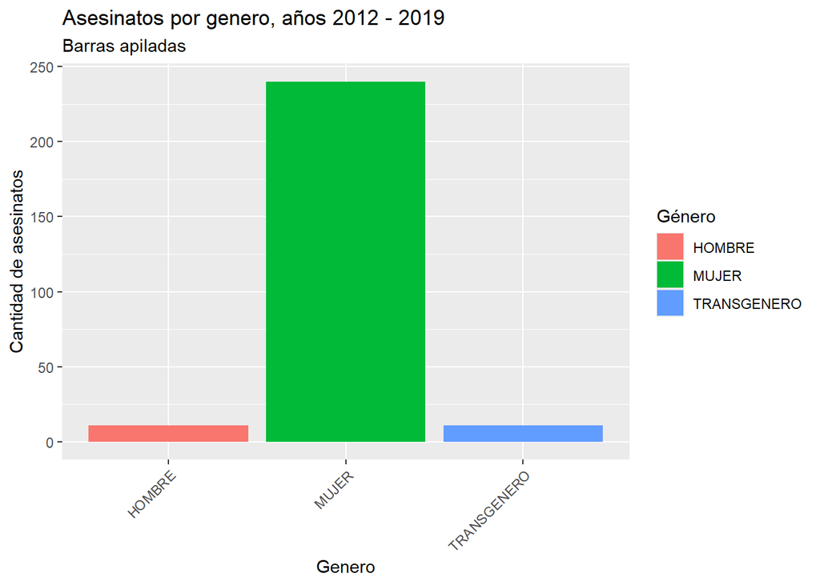

```r
#Grafico de barras agrupadas donde se observa la cantidad de femicidios, homicidios y trans/travesticidios por genero

grafico_total <- df_1_limpio %>%
  select(hecho_modalidad_comisiva, victima_identidad_genero) %>%
  group_by(hecho_modalidad_comisiva, victima_identidad_genero) %>%
  summarise(count = n(), .groups = "drop") %>%
  ggplot(aes(x = victima_identidad_genero, y = count, fill = victima_identidad_genero)) +
  geom_bar(stat = "identity", position = "dodge") +
  labs(
    title = "Asesinatos por genero, años 2012 - 2019",
    subtitle = "Barras apiladas",
    x = "Genero",
    y = "Cantidad de asesinatos",
    fill = "Género"
  ) +
  theme(axis.text.x = element_text(angle = 45, hjust = 1))

print(grafico_total)
```

Se observa que **los femicidios representan la mayor proporción de asesinatos por cuestión de género** registrados entre los años 2012 y 2019 en Argentina. La cantidad de casos en los que las víctimas son mujeres supera ampliamente a los homicidios de varones y a los trans/travesticidios, evidenciando una marcada desigualdad en la distribución de la violencia letal por género.

Sin embargo, en el caso de los **trans/travesticidios**, no resulta redundante señalar que la cantidad de casos debe analizarse en relación con la menor proporción de personas trans en la población total. Por lo tanto, si bien el número absoluto de hechos es menor, esto no implica necesariamente una menor incidencia de la violencia hacia este grupo, sino que debe considerarse su situación de mayor vulnerabilidad y **menor representación demográfica**.

**b) ¿Qué genero registra mayor ensañamiento según modalidad de asesinato?**

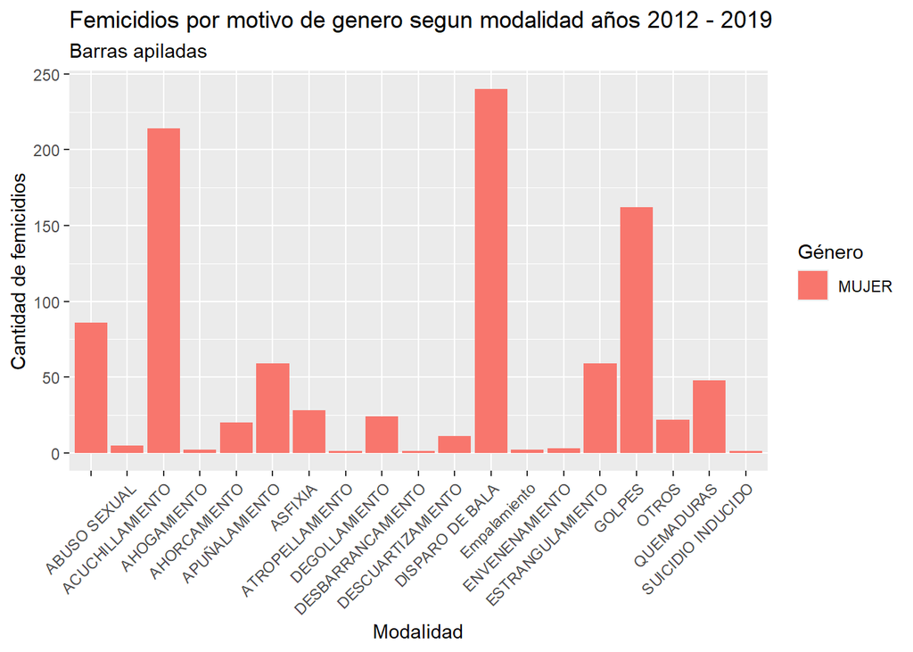

```r
#primero filtre por fem

df_1_limpio_filtrado_genero_fem <- df_1_limpio %>%
  filter(!victima_identidad_genero %in% c("HOMBRE", "TRANSGENERO"))

##grafiqué
grafico_fem <- df_1_limpio_filtrado_genero_fem %>%
  select(hecho_modalidad_comisiva, victima_identidad_genero) %>%
  unnest(hecho_modalidad_comisiva) %>%
  group_by(hecho_modalidad_comisiva, victima_identidad_genero) %>%
  summarise(count = n(), .groups = "drop") %>%
  ggplot(aes(x = hecho_modalidad_comisiva, y = count, fill = victima_identidad_genero)) +
  geom_bar(stat = "identity", position = "dodge") +
  labs(
    title = "Femicidios por motivo de genero segun modalidad años 2012 - 2019",
    subtitle = "Barras apiladas",
    x = "Modalidad",
    y = "Cantidad de femicidios",
    fill = "Género"
  ) +
  theme(axis.text.x = element_text(angle = 45, hjust = 1))

print(grafico_fem)
```

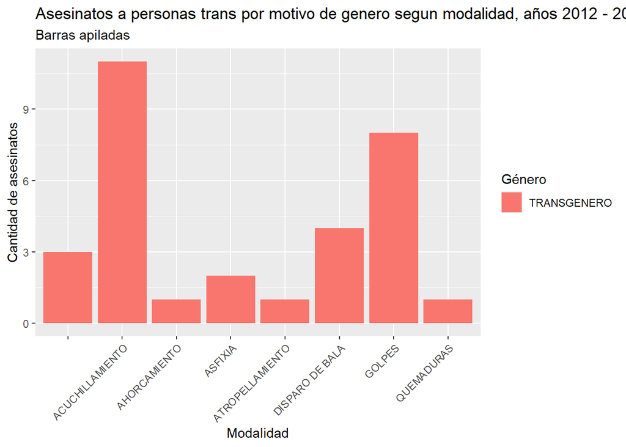

```r
#Despues por trans

df_1_limpio_filtrado_genero_trans <- df_1_limpio %>%
  filter(!victima_identidad_genero %in% c("HOMBRE", "MUJER"))

##grafiqué
grafico_trans <- df_1_limpio_filtrado_genero_trans %>%
  select(hecho_modalidad_comisiva, victima_identidad_genero) %>%
  unnest(hecho_modalidad_comisiva) %>%
  group_by(hecho_modalidad_comisiva, victima_identidad_genero) %>%
  summarise(count = n(), .groups = "drop") %>%
  ggplot(aes(x = hecho_modalidad_comisiva, y = count, fill = victima_identidad_genero)) +
  geom_bar(stat = "identity", position = "dodge") +
  labs(
    title = "Asesinatos a personas trans por motivo de genero segun modalidad, años 2012 - 2019",
    subtitle = "Barras apiladas",
    x = "Modalidad",
    y = "Cantidad de asesinatos",
    fill = "Género"
  ) +
  theme(axis.text.x = element_text(angle = 45, hjust = 1))

print(grafico_trans)
```

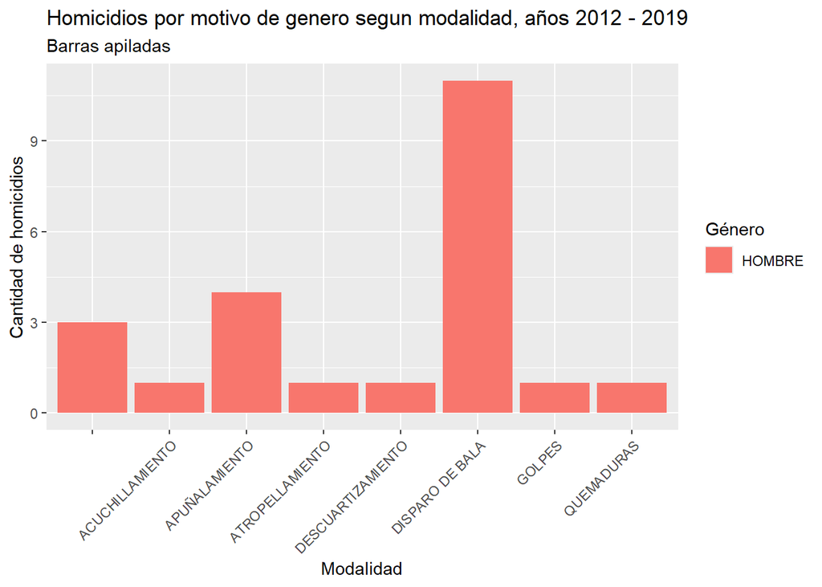

```r
#y finalmente por hom

df_1_limpio_filtrado_genero_hom <- df_1_limpio %>%
  filter(!victima_identidad_genero %in% c("MUJER", "TRANSGENERO"))

#"grafiqué
grafico_hom <- df_1_limpio_filtrado_genero_hom %>%
  select(hecho_modalidad_comisiva, victima_identidad_genero) %>%
  unnest(hecho_modalidad_comisiva) %>%
  group_by(hecho_modalidad_comisiva, victima_identidad_genero) %>%
  summarise(count = n(), .groups = "drop") %>%
  ggplot(aes(x = hecho_modalidad_comisiva, y = count, fill = victima_identidad_genero)) +
  geom_bar(stat = "identity", position = "dodge") +
  labs(
    title = "Homicidios por motivo de genero segun modalidad, años 2012 - 2019",
    subtitle = "Barras apiladas",
    x = "Modalidad",
    y = "Cantidad de homicidios",
    fill = "Género"
  ) +
  theme(axis.text.x = element_text(angle = 45, hjust = 1))
print(grafico_hom)
```

A partir de los gráficos se observa que mientras que en los asesinatos por motivos de genero entre hombres y mujeres prevalece la modalidad “Disparo de bala”, entre las población travesti/trans prevalece en primer lugar “Acuchillamiento” y luego “Golpes”.

Concluímos que aquellos **asesinatos por motivo de genero con mayor saña son los trans/travesticidios**.

Sin embargo no es menor señalar el hecho de que dada la amplia diversificación de modalidades de asesinato que hay entre los **femicidios** podemos intuir que entre los femicidios **prevalece también un alto nivel de saña**.

## 6 Visualizaciones (2): mapas

**c) ¿En qué provincias de Argentina hay más femicidios?**

Cargamos los datos geoespaciales

```r
# ---  Cargamos las librerías que vamos a usar
library(tidyverse)
library(sf) # Para trabajar con datos geoespaciales
library(geoAr)
## Carga poligonos geográficos de provincias argentinas
provincias_sf <- get_geo(geo = "ARGENTINA", level = "provincia")
## Cargar los nombres de las provincias
etiquetas_provincias <- show_arg_codes(nivel = "provincias") %>%
  select(codprov_censo , name_iso)
## unir nombres a df de poligonos
provincias_sf <- provincias_sf %>%
  left_join(etiquetas_provincias, by = "codprov_censo")

# creamos la tabla
femicidios_prov <- df_femicidios %>%
  group_by(hecho_provincia_id) %>%
  summarise(suma_femicidio_prov = n_distinct(caso_numero))
```

Mapa 1: Mapa de coropletas/de calor

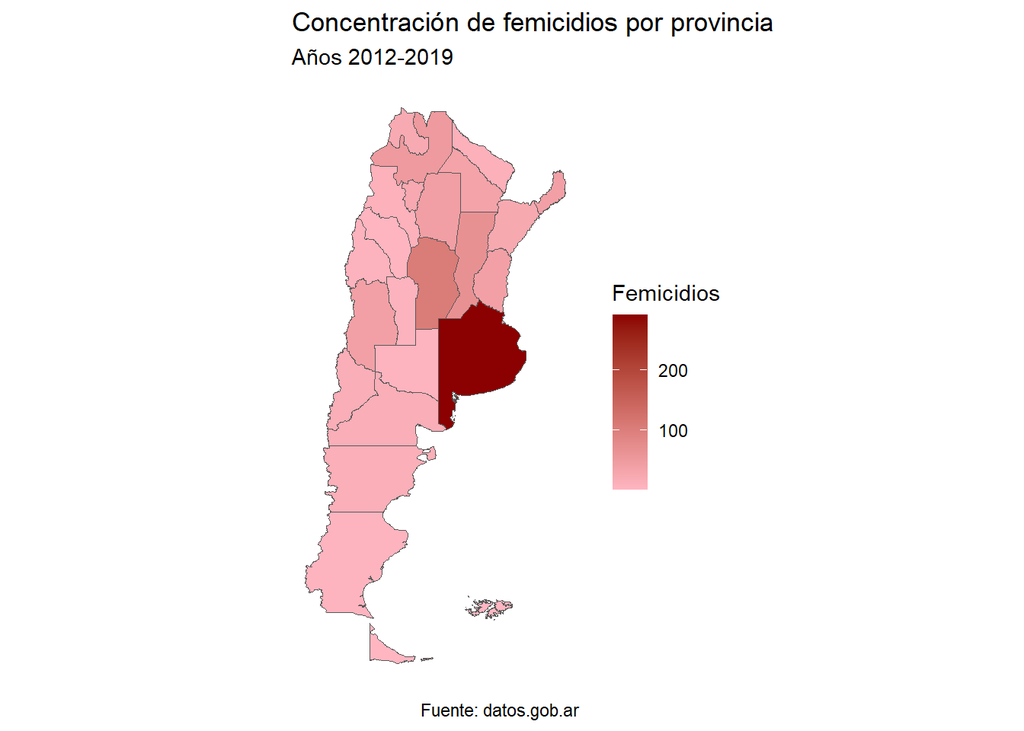

```r
#grafiqué mapa de calor simple (coropletas)

grafico_concentracion_femicidios_provincia <- provincias_sf %>%
  mutate(codprov_censo = as.integer(codprov_censo)) %>%
  left_join(femicidios_prov, by = c("codprov_censo" = "hecho_provincia_id")) %>%
  ggplot()+
  # usamos el valor de resumen como relleno para cada geometria
  geom_sf(aes(fill = suma_femicidio_prov ))+
  #agrego colores hechos con gpt
  scale_fill_gradient(
    low = "lightpink",
    high = "red4",
    na.value = "gray90",
    name = "Femicidios"
  )+
  labs(title = "Concentración de femicidios por provincia",
       subtitle = "Años 2012-2019",
       fill = "Cantidad de femicidios",
       caption = "Fuente: datos.gob.ar") +
  theme_minimal() +
  theme(axis.title = element_blank(),
        axis.text = element_blank(),
        panel.grid.major = element_blank(),
        panel.background = element_blank())
print(grafico_concentracion_femicidios_provincia)
```

Mapa 2

```r
#c.
# Unimos los datos de conteo de bibliotecas al objeto espacial de provincias para Leaflet
# Replicamos la unión hecha previamente
provincias_con_datos_leaflet <- provincias_sf %>%
  # convierto el tipo de variable para unir
  mutate(hecho_provincia_id = as.integer(codprov_censo)) %>%
  # unimos la tabla de resumen a la geometrias de provincias
  left_join(femicidios_prov, by = "hecho_provincia_id") %>%
  # Rellenar con 0 la cantidad de bibliotecas en provincias donde no hay registros
  mutate(suma_femicidio_prov = replace_na(suma_femicidio_prov, 0))


# Creamos una paleta de colores para el mapa interactivo de coropletas
pal_leaflet <- colorNumeric(
  # Hay varias podes elegir otra paleta si prefieres, consulta ?colorNumeric
  palette = "YlGnBu", # Por ejemplo, Yellow-Green-Blue
  domain = provincias_con_datos_leaflet$suma_femicidio_prov # El rango de valores a colorear
)

# Crear mapa leaflet
mapa_femicidios_leaflet <- leaflet(data = provincias_con_datos_leaflet) %>%
  addPolygons( # Añade los polígonos de las provincias
    fillColor = ~pal_leaflet(suma_femicidio_prov), # Rellena usando la paleta y la cantidad de bibliotecas
    fillOpacity = 0.8, # Opacidad del relleno
    color = "white", # Color del borde de los polígonos
    weight = 1, # Grosor del borde
    # Información al pasar el mouse (etiquetas)
    label = ~paste0(name_iso, ": ", suma_femicidio_prov, " femicidios"),
    # Opcional: Información al hacer clic (popup)
    popup = ~paste("</b><br>Femicidios: ", suma_femicidio_prov)
  ) %>%
  # Añade la leyenda de color
  addLegend(pal = pal_leaflet, values = ~suma_femicidio_prov, title = "Cant. Femicidios") %>%
  # Opcional: Ajustar la vista inicial
  setView(lng = -64, lat = -34, zoom = 4) # Centrar en Argentina

mapa_femicidios_leaflet
```

[interactive chart not shown]

A partir de los gráficos de mapas se observa, tal como se esperaba dados los datos de población total, que la **mayor cantidad de femicidios** se encuentra en la **Provincia de Buenos Aires**.

Sin embargo resulta fundamental para próximos proyectos trabajar con cantidad de femicidios sobre 100 mil habitantes para obtener la media de femicidios por provincia y desarrollar resultados más complejos.